# Open Data - Discovering Opportunities

Sister Analyst

24/05/2023

## Introduction

We will create a data analysis report about air pollution in Nis with the explanation of the R code used. Data that will be used for the analysis comes from the stations, which are set up by an independent initiative [Vazduh Gradjanima](https://vazduhgradjanima.rs)

Data is not frilly available with a single click, and we need to do some investigation. From the map https://maps.sensor.community/#9/43.4655/21.3952 we can identify the klimerko stations in Nis and download their readings from https://archive.sensor.community/2023-05-22/. The readings are then combined into a single csv file ‘data_nis.csv’ that is made available from our GitHub.

Once we have downloaded our data, we will start our workshop by installing [R](https://r-project.org) and [RStudio](https://www.rstudio.com), by following the instructions available on this link: [Install R i RStudia](https://instalirajr.netlify.app).

To learn how to use [R](https://cran.r-project.org/) and develop a report like this visit [Data Challenge Platform](https://datachallengewithr.rbind.io) with learning material developed in partnership with [UNDP Serbia](http://www.rs.undp.org). In particular we will focus on matirijal [Day 1](https://datachallengewithr.rbind.io/day1/) and [Day 2](https://datachallengewithr.rbind.io/day2/).

After we get familiar with the basic R syntax and data wrangling using data available from the open data portal Republic of Serbia https://data.gov.rs/sr/, we can dig into the air pollution data set following the instructions given below.

## Air pollution case study

### Reading and organising data

We will start the analysis by uploading the necessary packages and data into R.

If you have not got the packages used in the following code, you will need to uncomment the first few lines (delete the `#` symbol) in the code below.

```r
> #install.packages("rmarkdown")
> #install.packages("leaflet")
> #install.packages("lubridate")
> #install.packages("dplyr")
> #install.packages("tidyverse")
> #install.packages("DT")
>
> library(leaflet)
> suppressPackageStartupMessages(library(lubridate))
> suppressPackageStartupMessages(library(dplyr))
> suppressPackageStartupMessages(library(tidyverse))
>
> mydata <- read.csv('data/data_nis.csv',
+                    header=T)
```

It is always a good idea to have a look at data you upload, before you start using it for your analysis.

```r
> # scan data
> glimpse(mydata)
```

```
## Rows: 3,384
## Columns: 8
## $ sensor_id   <int> 22673, 22673, 22673, 22673, 22673, 22673, 22673, 22673, 22…
## $ sensor_type <chr> "SDS011", "SDS011", "SDS011", "SDS011", "SDS011", "SDS011"…
## $ location    <int> 11504, 11504, 11504, 11504, 11504, 11504, 11504, 11504, 11…
## $ lat         <dbl> 43.334, 43.334, 43.334, 43.334, 43.334, 43.334, 43.334, 43…
## $ lon         <dbl> 21.918, 21.918, 21.918, 21.918, 21.918, 21.918, 21.918, 21…
## $ timestamp   <chr> "2023-05-22T00:02:26", "2023-05-22T00:07:04", "2023-05-22T…
## $ P1          <dbl> 12, 13, 13, 13, 13, 13, 13, 13, 13, 13, 13, 13, 14, 14, 15…
## $ P2          <dbl> 12, 12, 12, 12, 12, 12, 13, 13, 13, 13, 13, 13, 14, 14, 14…
```

We can do some tweaking, by removing a few variables and separating day from time and creating separate columns for latitude and longitude variables.

```r
> # separate date from time
> mydata <- separate(mydata, timestamp, c("date", "time"), sep = "T")
> ## remove the last character from the `time` variable
> mydata$time <- (str_sub(mydata$time, end = -1))
> # scan data
> glimpse(mydata)
```

```
## Rows: 3,384
## Columns: 9
## $ sensor_id   <int> 22673, 22673, 22673, 22673, 22673, 22673, 22673, 22673, 22…
## $ sensor_type <chr> "SDS011", "SDS011", "SDS011", "SDS011", "SDS011", "SDS011"…
## $ location    <int> 11504, 11504, 11504, 11504, 11504, 11504, 11504, 11504, 11…
## $ lat         <dbl> 43.334, 43.334, 43.334, 43.334, 43.334, 43.334, 43.334, 43…
## $ lon         <dbl> 21.918, 21.918, 21.918, 21.918, 21.918, 21.918, 21.918, 21…
## $ date        <chr> "2023-05-22", "2023-05-22", "2023-05-22", "2023-05-22", "2…
## $ time        <chr> "00:02:26", "00:07:04", "00:11:42", "00:16:19", "00:20:55"…
## $ P1          <dbl> 12, 13, 13, 13, 13, 13, 13, 13, 13, 13, 13, 13, 14, 14, 15…
## $ P2          <dbl> 12, 12, 12, 12, 12, 12, 13, 13, 13, 13, 13, 13, 14, 14, 14…
```

```r
> ## remove 2nd and the last column
> mydata <- mydata[, -c(2, 3)]
```

We will check how many unique records each variable in our data has.

```r
> (uniq <- unlist(lapply(mydata, function(x) length(unique(x)))))
```

```
## sensor_id       lat       lon      date      time        P1        P2
##        10         9        10         1      2961       668       424
```

To us it is most interesting to notice that we have `10` stations in total. Next, we’ll check if all of the stations are active, by examining the number of readings for each station.

```r
> # how many reading each station makes
> mydata %>%
+   group_by(sensor_id) %>%
+   summarise(no_readings = n()) %>%
+   arrange(no_readings) %>%
+   DT::datatable()
```

|  | sensor_id | no_readings |
| --- | --- | --- |
| 1 | 53939 | 37 |
| 2 | 54299 | 97 |
| 3 | 40367 | 279 |
| 4 | 68224 | 287 |
| 5 | 22673 | 292 |
| 6 | 21120 | 308 |
| 7 | 22675 | 308 |
| 8 | 53835 | 501 |
| 9 | 52816 | 574 |
| 10 | 72906 | 701 |

There are all active and are providing the reading.

### Mapping the stations

To see where the stations are allocated we will plot them on Google maps. We will use the `leaflet` package to do this and create a sub data with only a list of the stations and their positions.

```r
> mydata[,1] <- as.factor(mydata[,1])
> summary(mydata)
```

```
##    sensor_id        lat             lon            date
##  72906  :701   Min.   :43.31   Min.   :21.88   Length:3384
##  52816  :574   1st Qu.:43.31   1st Qu.:21.90   Class :character
##  53835  :501   Median :43.32   Median :21.92   Mode  :character
##  21120  :308   Mean   :43.32   Mean   :21.91
##  22675  :308   3rd Qu.:43.33   3rd Qu.:21.92
##  22673  :292   Max.   :43.33   Max.   :21.94
##  (Other):700
##      time                 P1               P2
##  Length:3384        Min.   : 1.420   Min.   : 1.20
##  Class :character   1st Qu.: 6.000   1st Qu.: 3.70
##  Mode  :character   Median : 8.430   Median : 5.60
##                     Mean   : 8.937   Mean   : 6.02
##                     3rd Qu.:10.800   3rd Qu.: 7.00
##                     Max.   :77.930   Max.   :45.05
##
```

```r
> # creating a dataframe with only names and lat & lng for each station
> stations <- data.frame(mydata[,c(1:3)]) %>%
+   drop_na()
> stations [, 2] <- as.numeric(as.character(stations[,2]))
> stations [, 3] <- as.numeric(as.character(stations[,3]))
> summary(stations)
```

```
##    sensor_id        lat             lon
##  72906  :701   Min.   :43.31   Min.   :21.88
##  52816  :574   1st Qu.:43.31   1st Qu.:21.90
##  53835  :501   Median :43.32   Median :21.92
##  21120  :308   Mean   :43.32   Mean   :21.91
##  22675  :308   3rd Qu.:43.33   3rd Qu.:21.92
##  22673  :292   Max.   :43.33   Max.   :21.94
##  (Other):700
```

Once we have the subset data we can plot it using the `leaflet` package as below.

```r
> minlat <- min(stations$lat)
> maxlat <- max(stations$lat)
> minlng <- min(stations$lon)
> maxlng <- max(stations$lon)
>
> stations %>%
+   group_by(sensor_id, lat, lon) %>%
+   leaflet() %>%
+   addTiles() %>%
+   fitBounds(~minlng, ~minlat, ~maxlng, ~maxlat) %>%
+   addCircles(lng = ~lon, lat = ~lat,
+              radius = 150, weight = 5, color = "black",
+              fillColor = "red", fillOpacity = 0.7,
+              popup = ~paste("<b>", sensor_id)
+   )
```

[interactive chart not shown]

### Analysing the readings

In this section we will look through the readings and try to make some sense of it all. If you are not familiar with the information collected by the stations, ie. about the pm particles you can check the following link: https://www.irceline.be/en/documentation/faq/what-is-pm10-and-pm2.5.

#### Average concentration of particles each hour

```r
> mydata$time <- factor(mydata$time)
> mydata$time <- hms(as.character(mydata$time))
>
> mydata %>%
+   group_by(hour(time)) %>%
+   summarise(no_readings = n()) %>%
+   DT::datatable()
```

|  | hour(time) | no_readings |
| --- | --- | --- |
| 1 | 0 | 146 |
| 2 | 1 | 113 |
| 3 | 2 | 150 |
| 4 | 3 | 139 |
| 5 | 4 | 140 |
| 6 | 5 | 147 |
| 7 | 6 | 137 |
| 8 | 7 | 151 |
| 9 | 8 | 142 |
| 10 | 9 | 134 |

[output cut: 14 more lines]

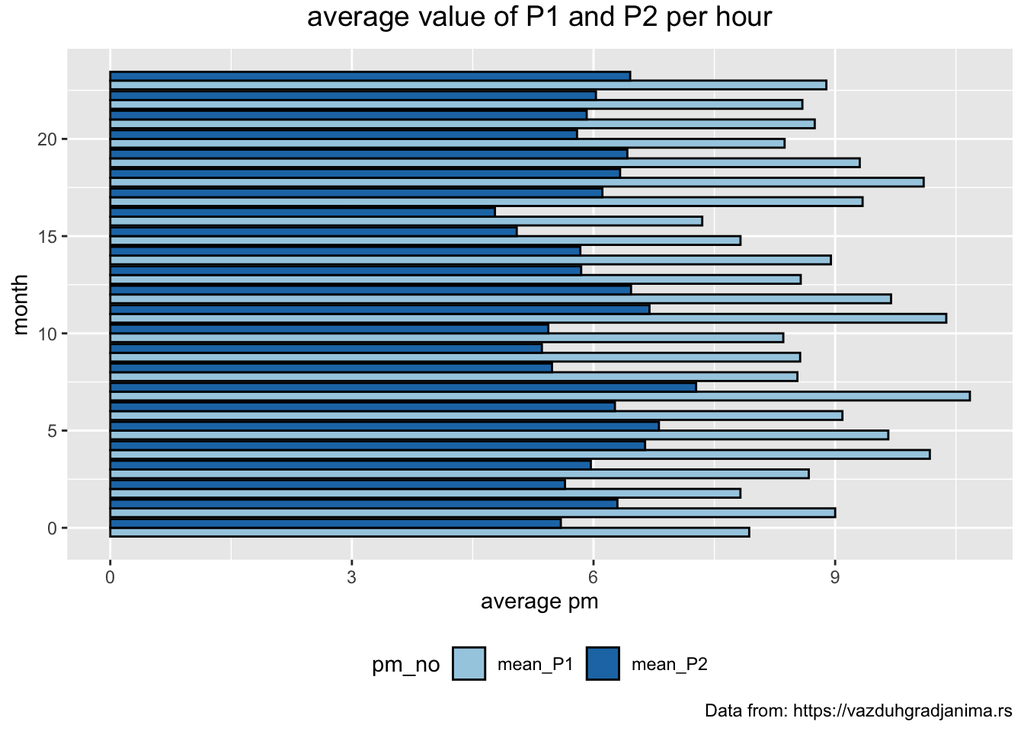

```r
> mydata%>%
+   group_by(hour(time)) %>%
+   summarise(mean_P1 = mean(P1, na.rm = TRUE), mean_P2 = mean(P2, na.rm = TRUE)) %>%
+   gather("pm_no", "mean_pm", -`hour(time)`, factor_key = TRUE) %>%
+   ggplot(aes(x = `hour(time)`, y = mean_pm, fill = pm_no )) +
+   geom_bar(stat="identity", position = "dodge", color = "black") +
+   coord_flip() +
+   theme(plot.title = element_text(size = 14, vjust = 2, hjust=0.5)) +
+   labs (title = "average value of P1 and P2 per hour",
+         caption = "Data from: https://vazduhgradjanima.rs",
+         x = "month", y = "average pm") +
+   scale_fill_brewer(palette="Paired") +
+   theme(legend.position="bottom")
```